# Volatility Analysis of the South African Rand

André le Roux

November 2024

### Abstract

This report will analyse the individual and comparative volatility of the South African Rand within the context of other global countries. Thus, getting a more well rounded understanding of the volatility of the Rand.

# Data

The Data used in this report consists of daily level exchange rate data, daily data for the Bloomberg Dollar Spot Index (BBDXY), which is the value of the US Dollar in comparison to other G10 country currencies and the Deutsche Bank G10 Harvest Index as a proxy for the returns of a carry strategy of G10 currencies.

# Analysis

The first graph is a simple ranking of the annualised standard deviation over the past 5 years for all currencies in our dataset. This gives us a rough first estimate of the relative volatility of the Rand in comparison to other currencies.

##### Figure 1:

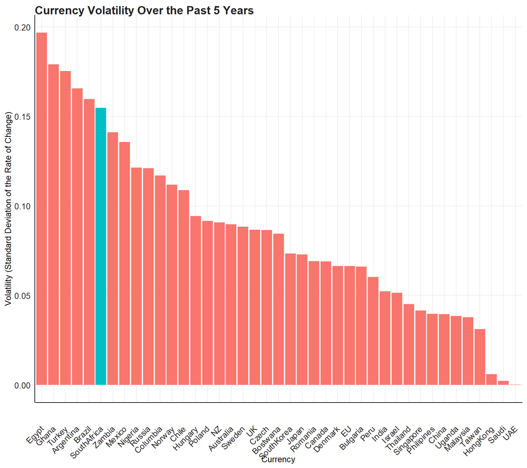

In order to get a more accurate prediction of variance I look at the rate of change persistence of the South African Rand to look for any signs of first order and second order persistence.

##### Figure 2:

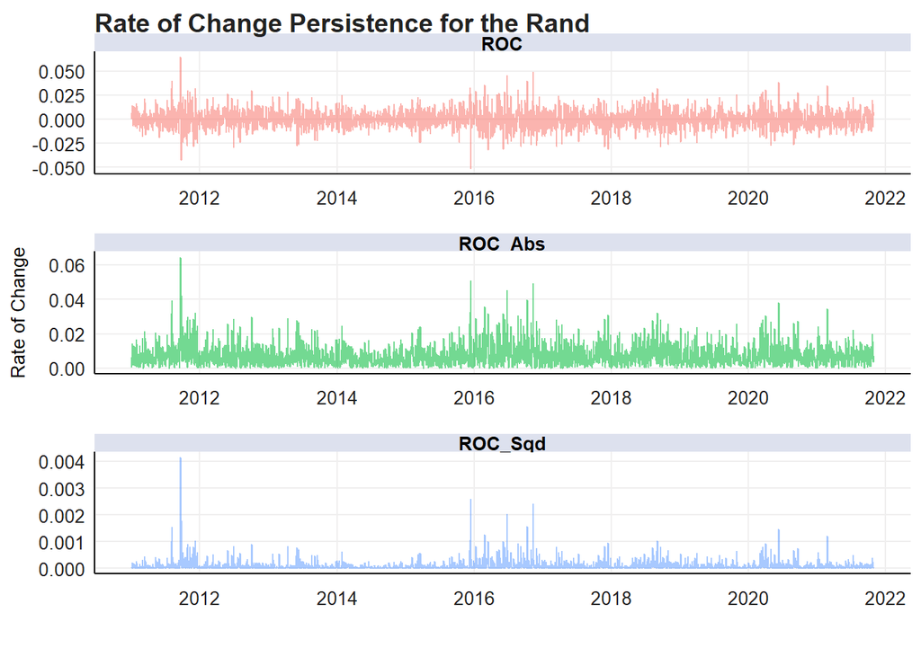

It appears clear from *figure 2* that there is first and second order persistence, however I also conducted a Ljung-Box test which returned a p-value of 0. Thereby strongly suggesting the use of a GARCH model.

The next step I do is to implement the GARCH and graph the difference in sigma’s with and without the GARCH model to demonstrate it’s effects.